Naive-Bayes Analysis of Adult Income

In [1]:

Name = "Zachary Kekoa"

Description

The goal of this project is to use the Naive-Bayes method and Logistic Regression method to classify whether an individual makes over $\$50,000$ or $\$50,000$ or less (> 50k or <= 50k) based on features such as age, education, occupation, etc. Each row represents a different individual and compare which model was better. Data was collected from https://www.kaggle.com/datasets/wenruliu/adult-income-dataset

Import Libraries

In [1]:

import pandas as pd

import matplotlib.pyplot as plt

import numpy as np

from sklearn.preprocessing import OrdinalEncoder # for encoding categorical features from strings to number arrays

from sklearn.naive_bayes import MultinomialNB, CategoricalNB

from sklearn.metrics import confusion_matrix

from sklearn.metrics import accuracy_score

Import Data

In [2]:

adult = pd.read_csv('adult.csv', sep = ',')

adult.head()

Out[2]:

|  | age | workclass | fnlwgt | education | educational-num | marital-status | occupation | relationship | race | gender | capital-gain | capital-loss | hours-per-week | native-country | income |
| --- | --- | --- | --- | --- | --- | --- | --- | --- | --- | --- | --- | --- | --- | --- | --- |
| 0 | 25 | Private | 226802 | 11th | 7 | Never-married | Machine-op-inspct | Own-child | Black | Male | 0 | 0 | 40 | United-States | <=50K |
| 1 | 38 | Private | 89814 | HS-grad | 9 | Married-civ-spouse | Farming-fishing | Husband | White | Male | 0 | 0 | 50 | United-States | <=50K |
| 2 | 28 | Local-gov | 336951 | Assoc-acdm | 12 | Married-civ-spouse | Protective-serv | Husband | White | Male | 0 | 0 | 40 | United-States | >50K |
| 3 | 44 | Private | 160323 | Some-college | 10 | Married-civ-spouse | Machine-op-inspct | Husband | Black | Male | 7688 | 0 | 40 | United-States | >50K |
| 4 | 18 | ? | 103497 | Some-college | 10 | Never-married | ? | Own-child | White | Female | 0 | 0 | 30 | United-States | <=50K |

Fitting the Model

In [3]:

# check value counts of our label

adult['income'].value_counts(normalize=True)

Out[3]:

<=50K 0.760718

>50K 0.239282

Name: income, dtype: float64

In [4]:

# set seed

np.random.seed(123)

# Randomize the dataset

data_randomized = adult.sample(frac = 1)

# Calculate index for 80:20 split

trainsize = round(len(data_randomized) * 0.8)

# Split into training and test sets

training_set = data_randomized[:trainsize].reset_index(drop=True)

test_set = data_randomized[trainsize:].reset_index(drop=True)

print(training_set.shape)

print(test_set.shape)

(39074, 15)

(9768, 15)

In [5]:

# sanity check

print(type(training_set))

training_set.head(6)

<class 'pandas.core.frame.DataFrame'>

Out[5]:

|  | age | workclass | fnlwgt | education | educational-num | marital-status | occupation | relationship | race | gender | capital-gain | capital-loss | hours-per-week | native-country | income |
| --- | --- | --- | --- | --- | --- | --- | --- | --- | --- | --- | --- | --- | --- | --- | --- |
| 0 | 52 | Private | 117700 | HS-grad | 9 | Divorced | Adm-clerical | Not-in-family | White | Female | 0 | 0 | 40 | United-States | <=50K |
| 1 | 19 | Private | 351757 | 10th | 6 | Never-married | Other-service | Unmarried | White | Male | 0 | 0 | 30 | El-Salvador | <=50K |
| 2 | 31 | Federal-gov | 101345 | HS-grad | 9 | Never-married | Handlers-cleaners | Own-child | White | Female | 0 | 0 | 40 | United-States | <=50K |
| 3 | 25 | Private | 324854 | Bachelors | 13 | Never-married | Sales | Not-in-family | White | Female | 0 | 0 | 40 | United-States | <=50K |
| 4 | 36 | Private | 245521 | 7th-8th | 4 | Married-civ-spouse | Farming-fishing | Husband | White | Male | 0 | 0 | 35 | Mexico | <=50K |
| 5 | 50 | Private | 144084 | Bachelors | 13 | Divorced | Adm-clerical | Not-in-family | White | Female | 0 | 0 | 40 | United-States | <=50K |

In [6]:

# make sure training set proportions are similar to original df

training_set['income'].value_counts(normalize=True)

Out[6]:

<=50K 0.760301

>50K 0.239699

Name: income, dtype: float64

In [7]:

# make sure test set proportions are similar to original df

test_set['income'].value_counts(normalize=True)

Out[7]:

<=50K 0.762387

>50K 0.237613

Name: income, dtype: float64

Creating The Model

In [8]:

trainX = training_set.iloc[:,:-1]

trainy = training_set['income']

colnames = trainX.columns

trainX.head()

Out[8]:

|  | age | workclass | fnlwgt | education | educational-num | marital-status | occupation | relationship | race | gender | capital-gain | capital-loss | hours-per-week | native-country |
| --- | --- | --- | --- | --- | --- | --- | --- | --- | --- | --- | --- | --- | --- | --- |
| 0 | 52 | Private | 117700 | HS-grad | 9 | Divorced | Adm-clerical | Not-in-family | White | Female | 0 | 0 | 40 | United-States |
| 1 | 19 | Private | 351757 | 10th | 6 | Never-married | Other-service | Unmarried | White | Male | 0 | 0 | 30 | El-Salvador |
| 2 | 31 | Federal-gov | 101345 | HS-grad | 9 | Never-married | Handlers-cleaners | Own-child | White | Female | 0 | 0 | 40 | United-States |
| 3 | 25 | Private | 324854 | Bachelors | 13 | Never-married | Sales | Not-in-family | White | Female | 0 | 0 | 40 | United-States |
| 4 | 36 | Private | 245521 | 7th-8th | 4 | Married-civ-spouse | Farming-fishing | Husband | White | Male | 0 | 0 | 35 | Mexico |

In [9]:

testX = test_set.iloc[:,:-1]

testy = test_set['income']

colnames = testX.columns

testX.head()

Out[9]:

|  | age | workclass | fnlwgt | education | educational-num | marital-status | occupation | relationship | race | gender | capital-gain | capital-loss | hours-per-week | native-country |
| --- | --- | --- | --- | --- | --- | --- | --- | --- | --- | --- | --- | --- | --- | --- |
| 0 | 17 | Private | 181580 | 11th | 7 | Never-married | Other-service | Own-child | White | Female | 0 | 0 | 16 | United-States |
| 1 | 18 | Private | 205218 | 11th | 7 | Never-married | Sales | Own-child | White | Female | 0 | 0 | 20 | United-States |
| 2 | 27 | Local-gov | 298510 | HS-grad | 9 | Divorced | Protective-serv | Own-child | White | Male | 0 | 0 | 40 | United-States |
| 3 | 37 | Private | 196338 | 9th | 5 | Separated | Priv-house-serv | Unmarried | White | Female | 0 | 0 | 16 | Mexico |
| 4 | 38 | Local-gov | 218763 | Masters | 14 | Separated | Prof-specialty | Unmarried | White | Female | 0 | 0 | 40 | United-States |

Encoding and Training

I will create and fit an NB model on both the train and the test data to display the bias-variance tradeoff through the accuracy of the models.

Train Data

In [10]:

from sklearn.preprocessing import LabelEncoder

le = LabelEncoder()

#0-1 encoding train labels

trainBrnli = le.fit_transform(trainy)

Out[10]:

In [11]:

from sklearn.preprocessing import OrdinalEncoder

enc = OrdinalEncoder()

trainX = enc.fit_transform(trainX)

trainX = pd.DataFrame(trainX, columns=colnames)

trainX.head()

Out[11]:

|  | age | workclass | fnlwgt | education | educational-num | marital-status | occupation | relationship | race | gender | capital-gain | capital-loss | hours-per-week | native-country |
| --- | --- | --- | --- | --- | --- | --- | --- | --- | --- | --- | --- | --- | --- | --- |
| 0 | 35.0 | 4.0 | 6047.0 | 11.0 | 8.0 | 0.0 | 1.0 | 1.0 | 4.0 | 0.0 | 0.0 | 0.0 | 39.0 | 39.0 |
| 1 | 2.0 | 4.0 | 22373.0 | 0.0 | 5.0 | 4.0 | 8.0 | 4.0 | 4.0 | 1.0 | 0.0 | 0.0 | 29.0 | 8.0 |
| 2 | 14.0 | 1.0 | 4452.0 | 11.0 | 8.0 | 4.0 | 6.0 | 3.0 | 4.0 | 0.0 | 0.0 | 0.0 | 39.0 | 39.0 |
| 3 | 8.0 | 4.0 | 21544.0 | 9.0 | 12.0 | 4.0 | 12.0 | 1.0 | 4.0 | 0.0 | 0.0 | 0.0 | 39.0 | 39.0 |
| 4 | 19.0 | 4.0 | 18025.0 | 5.0 | 3.0 | 2.0 | 5.0 | 0.0 | 4.0 | 1.0 | 0.0 | 0.0 | 34.0 | 26.0 |

In [12]:

#create model object

model = CategoricalNB()

# fit on train data

model.fit(trainX,trainBrnli)

# predict on train data

yhattrain = model.predict(trainX)

Out[12]:

CategoricalNB()

In [14]:

#confusion matrix

confusion_matrix(yhattrain, trainBrnli)

Out[14]:

array([[25765, 1323],

[ 3943, 8043]], dtype=int64)

In [15]:

# accuracy

accuracy_score(yhattrain, trainBrnli)

Out[15]:

0.8652300762655474

Test Data

In [16]:

# same procedure, but with the test data

testBrnli = le.fit_transform(testy)

testX = enc.fit_transform(testX)

testX = pd.DataFrame(testX, columns=colnames)

model = CategoricalNB()

model.fit(trainX,trainBrnli)

yhattest = model.predict(testX)

In [17]:

confM = confusion_matrix(yhattest, testBrnli)

confM

Out[17]:

array([[6649, 891],

[ 798, 1430]], dtype=int64)

In [18]:

acc = accuracy_score(yhattest, testBrnli)

acc

Out[18]:

0.827088452088452

The accuracy of the test model is lower than the accuracy of the train model due to the bias-variance tradeoff phenomenon as the accuracy of the model will naturally decrease across other data samples. Since the accuracy of the test data is 82%, this means that this is a very effective model for predicting income level (> 50k or <= 50k).

Logistic Regression

Get Data

In [1]:

library(caTools)

library(pROC)

library(glmnet)

adult <- read.csv(file = "adult.csv", stringsAsFactors = FALSE)

dim(adult)

Warning message:

Attaching package: 'pROC'

The following objects are masked from 'package:stats':

cov, smooth, var

Warning message:

Warning message:

1. 48842
2. 15

In [2]:

head(adult)

| age | workclass | fnlwgt | education | educational.num | marital.status | occupation | relationship | race | gender | capital.gain | capital.loss | hours.per.week | native.country | income |
| --- | --- | --- | --- | --- | --- | --- | --- | --- | --- | --- | --- | --- | --- | --- |
| 25 | Private | 226802 | 11th | 7 | Never-married | Machine-op-inspct | Own-child | Black | Male | 0 | 0 | 40 | United-States | <=50K |
| 38 | Private | 89814 | HS-grad | 9 | Married-civ-spouse | Farming-fishing | Husband | White | Male | 0 | 0 | 50 | United-States | <=50K |
| 28 | Local-gov | 336951 | Assoc-acdm | 12 | Married-civ-spouse | Protective-serv | Husband | White | Male | 0 | 0 | 40 | United-States | >50K |
| 44 | Private | 160323 | Some-college | 10 | Married-civ-spouse | Machine-op-inspct | Husband | Black | Male | 7688 | 0 | 40 | United-States | >50K |
| 18 | ? | 103497 | Some-college | 10 | Never-married | ? | Own-child | White | Female | 0 | 0 | 30 | United-States | <=50K |
| 34 | Private | 198693 | 10th | 6 | Never-married | Other-service | Not-in-family | White | Male | 0 | 0 | 30 | United-States | <=50K |

Data Exploration/Transformation

In [3]:

# convert ? to NA values

adult[adult == "?"] <- NA

# remove NA values

adult1 <- adult[complete.cases(adult),]

# remove education, fnlwgt, capital.gain, and capital.loss

adult2 <- subset(adult1, select = -c(education, fnlwgt, capital.gain, capital.loss))

#convert target variable to 1 if >50K and 0 if <=50K

adult2["income"][adult2["income"] == ">50K"] <- 1

adult2["income"][adult2["income"] == "<=50K"] <- 0

adult2$income <- as.numeric(adult2$income)

In [4]:

head(adult2)

|  | age | workclass | educational.num | marital.status | occupation | relationship | race | gender | hours.per.week | native.country | income |
| --- | --- | --- | --- | --- | --- | --- | --- | --- | --- | --- | --- |
| 1 | 25 | Private | 7 | Never-married | Machine-op-inspct | Own-child | Black | Male | 40 | United-States | 0 |
| 2 | 38 | Private | 9 | Married-civ-spouse | Farming-fishing | Husband | White | Male | 50 | United-States | 0 |
| 3 | 28 | Local-gov | 12 | Married-civ-spouse | Protective-serv | Husband | White | Male | 40 | United-States | 1 |
| 4 | 44 | Private | 10 | Married-civ-spouse | Machine-op-inspct | Husband | Black | Male | 40 | United-States | 1 |
| 6 | 34 | Private | 6 | Never-married | Other-service | Not-in-family | White | Male | 30 | United-States | 0 |
| 8 | 63 | Self-emp-not-inc | 15 | Married-civ-spouse | Prof-specialty | Husband | White | Male | 32 | United-States | 1 |

In [5]:

# Ordinal encoding of categorical variables

encode_ordinal <- function(x, order = unique(x)) {

x <- as.numeric(factor(x, levels = order, exclude = NULL))

x

}

adult2[["workclass"]] <- encode_ordinal(adult2[["workclass"]])

adult2[["marital.status"]] <- encode_ordinal(adult2[["marital.status"]])

adult2[["occupation"]] <- encode_ordinal(adult2[["occupation"]])

adult2[["relationship"]] <- encode_ordinal(adult2[["relationship"]])

adult2[["race"]] <- encode_ordinal(adult2[["race"]])

adult2[["gender"]] <- encode_ordinal(adult2[["gender"]])

adult2[["native.country"]] <- encode_ordinal(adult2[["native.country"]])

In [6]:

head(adult2)

|  | age | workclass | educational.num | marital.status | occupation | relationship | race | gender | hours.per.week | native.country | income |
| --- | --- | --- | --- | --- | --- | --- | --- | --- | --- | --- | --- |
| 1 | 25 | 1 | 7 | 1 | 1 | 1 | 1 | 1 | 40 | 1 | 0 |
| 2 | 38 | 1 | 9 | 2 | 2 | 2 | 2 | 1 | 50 | 1 | 0 |
| 3 | 28 | 2 | 12 | 2 | 3 | 2 | 2 | 1 | 40 | 1 | 1 |
| 4 | 44 | 1 | 10 | 2 | 1 | 2 | 1 | 1 | 40 | 1 | 1 |
| 6 | 34 | 1 | 6 | 1 | 4 | 3 | 2 | 1 | 30 | 1 | 0 |
| 8 | 63 | 3 | 15 | 2 | 5 | 2 | 2 | 1 | 32 | 1 | 1 |

Build Model

In [7]:

# split dataset

split <- sample.split(adult2, SplitRatio = 0.8)

train <- subset(adult2, split == "TRUE")

test <- subset(adult2, split == "FALSE")

In [8]:

# fit the model

l_mod <- glm(income ~ ., data = train, family = "binomial")

summary(l_mod)

Call:

glm(formula = income ~ ., family = "binomial", data = train)

Deviance Residuals:

Min 1Q Median 3Q Max

-2.9403 -0.6772 -0.4168 -0.0859 3.1947

Coefficients:

Estimate Std. Error z value Pr(>|z|)

(Intercept) -7.018710 0.133954 -52.396 < 2e-16 ***

age 0.047956 0.001261 38.041 < 2e-16 ***

workclass 0.027577 0.010295 2.679 0.007390 **

educational.num 0.350998 0.006627 52.962 < 2e-16 ***

marital.status -0.145218 0.012977 -11.191 < 2e-16 ***

occupation 0.033493 0.005030 6.659 2.75e-11 ***

relationship 0.064315 0.016953 3.794 0.000148 ***

race 0.051912 0.024151 2.149 0.031597 *

gender -1.145525 0.042854 -26.731 < 2e-16 ***

hours.per.week 0.034344 0.001298 26.462 < 2e-16 ***

native.country -0.005018 0.003139 -1.599 0.109911

---

Signif. codes: 0 '***' 0.001 '**' 0.01 '*' 0.05 '.' 0.1 ' ' 1

(Dispersion parameter for binomial family taken to be 1)

Null deviance: 36861 on 32888 degrees of freedom

Residual deviance: 28731 on 32878 degrees of freedom

AIC: 28753

Number of Fisher Scoring iterations: 5

In [9]:

coef(l_mod)

(Intercept)

-7.01870963085234

age

0.0479562010345121

workclass

0.0275766555938961

educational.num

0.350997538080738

marital.status

-0.145218085216737

occupation

0.0334929741628935

relationship

0.064315159141858

race

0.0519121163316077

gender

-1.14552491633127

hours.per.week

0.0343437079863098

native.country

-0.00501812895663385

Therefore our fitted model is $\hat{\pi} = \hat{P}(y = 1|x) = \frac{1}{1 + e^{-z}}$, where $z = -7.02 + 0.05*age + 0.03*workclass + 0.35*educational.num - 0.15*marital.status + 0.03*occupation + 0.06*relationship + 0.05*race - 1.15*gender + 0.03*hours.per.week - 0.01*native.country$

Predict On Test Data

In [10]:

predict <- predict(l_mod, test, type = "response")

Evaluate Accuracy

In [11]:

# set threshold at s = 0.5 for yhat

predict <- ifelse(predict > 0.5, 1, 0)

# create confusion matrix

tbl = table(test$income, predict)

tbl

predict

0 1

0 8692 597

1 1875 1169

In [12]:

# accuracy

acc = (tbl[1,1] + tbl[2,2]) / sum(tbl)

acc

0.799562150328387

Since our NB model had an accuracy of $\approx 0.83$, the NB model is about $3\%$ better. However, either model is good as their accuracies are equal to or greater than $80\%$.

ROC curve

In [13]:

# build curve

y = (test$income == 1)

ROCcrv = roc(response = y, predictor = predict)

AUC = auc(ROCcrv)

#plot

plot(x = ROCcrv$specificities, y = ROCcrv$sensitivities,

main = paste("AUC = ", round(AUC,2)), xlab = "Specificity",

ylab = "Sensitivity", xlim = c(1,0), type = "l", col = "blue")

abline(a = 1, b = -1, lty = "dashed")

Setting levels: control = FALSE, case = TRUE

Setting direction: controls < cases

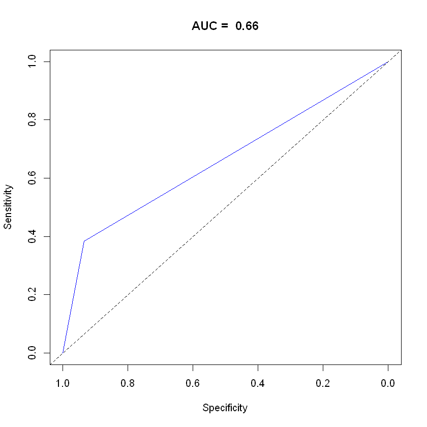

Ridge Regularization

In [14]:

y = adult2$income

x = as.matrix(adult2[ , names(adult2) != "income"])

cvfit = cv.glmnet(x, y, family = "binomial", type.measure = "deviance",

nfolds = 10, alpha = 0)

plot(cvfit)

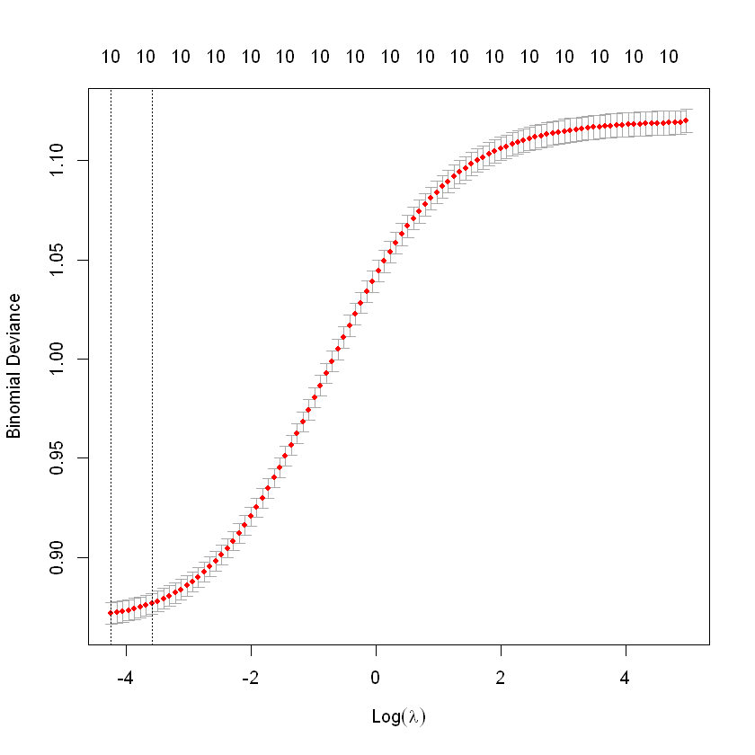

Lasso Regularization

In [16]:

cvfit = cv.glmnet(x, y, family = "binomial", type.measure = "deviance",

nfolds = 10, alpha = 1)

plot(cvfit)

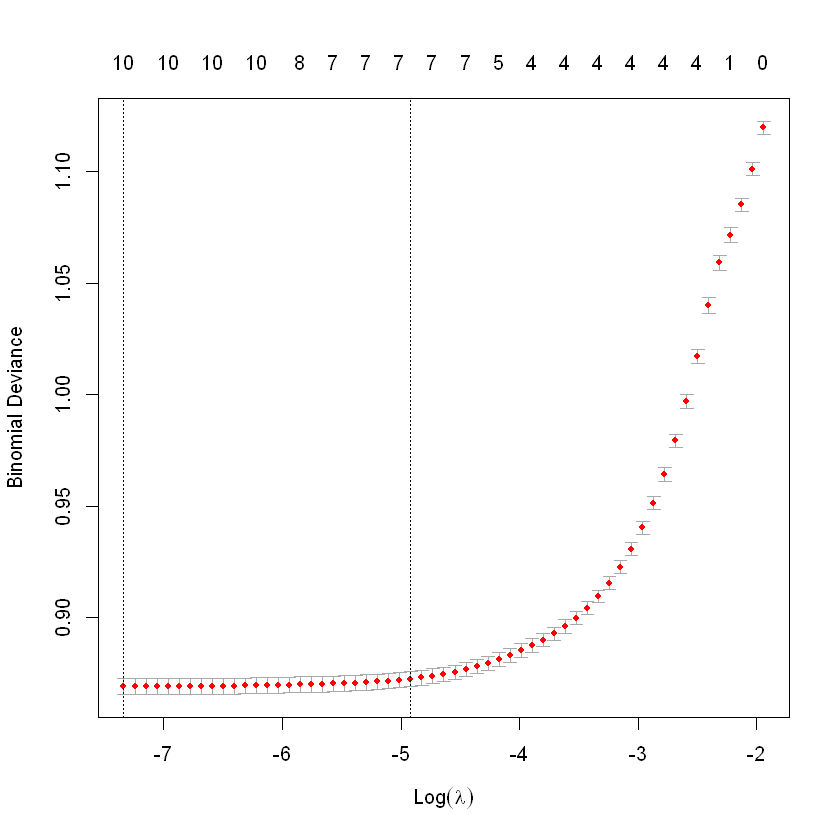

Conclusion/Future Work

Both the NB model and logistic regression model proved to be capable of classifying adult income given theses specific predictors. Another comparison could be done using a $k$NN model.

Additionally, I would like to know if the income variable could be broken down into smaller categories and even an exact numeric variable to try to use regression techniques to predict income.